# Assemble raw dataset for functions - calculations

Noelle Schenk, Eric Allan, Caterina Penone

May, 2019

# Dependence

This document depends on `1read_raw_datasets.Rmd` and needs `multidiversity.R`.

```r
source("multidiversity.R") # function by E. Allan
```

## knit to HTML

Use the following command to knit:

```r
rmarkdown::render("2calc_raw_dataset.Rmd")
```

# Biomass

## Biomass2009

Take as it is, because ranges are comparable to other years.

```r
Biomass2009 <- list_raw_functions$Biomass2009
# how different are 2009 values of other years?
plot(rep(2008, 150), raw_functions$Biomass2008, ylim= c(0, 2000), xlim=c(2007,2018))

points(rep(2010, 150), raw_functions$Biomass2010)
points(rep(2011, 150), raw_functions$Biomass2011)
points(rep(2012, 150), raw_functions$Biomass2012)
points(rep(2013, 150), raw_functions$Biomass2013)
points(rep(2014, 150), raw_functions$Biomass2014)
points(rep(2015, 150), raw_functions$Biomass2015)
points(rep(2016, 150), raw_functions$Biomass2016)
points(rep(2017, 150), raw_functions$Biomass2017)

points(rep(2009, 149), Biomass2009[Treatment == "K2", Biomass2009], col="green")
```

[output not shown]

attempts to correct it:

```r
Biomass2009 <- list_raw_functions$Biomass2009
Biomass2009 <- aggregate(Biomass2009~Plot, Biomass2009, mean)
raw_functions <- merge(raw_functions, Biomass2009, by = "Plot", all = T) ; rm(Biomass2009)
list_raw_functions["Biomass2009"] <- NULL
```

### linear model day vs. biomass

$$Biomass = -161.959 + (3.131 * day)$$
- Take + 30 days of Biomass production for all plots. - how much biomass is produced in 30 days? - add this value to all data points

```r
Biomass2009 <- list_raw_functions$Biomass2009
# construct linear model
# Biomass calculation as a function of day
# Biomass = -161.959 + (3.131 * day)
mod <- lm(Biomass2009 ~ Day_of_year, data=Biomass2009)
# summary(mod)


# newvalues
impBiomass2009I <- data.table::copy(Biomass2009)
impBiomass2009I[,"Day_of_year" := Day_of_year + 30]
data.table::setnames(impBiomass2009I, old="Biomass2009", new="oldBiomass2009")
impBiomass2009I[, "Biomass2009" := predict(mod, impBiomass2009I)]

# plot result
par(mfrow=c(1,2))
plot((impBiomass2009I$Day_of_year - 30)/30, impBiomass2009I$oldBiomass2009, col="darkgreen", xlim = c(4,6.6))
points((impBiomass2009I$Day_of_year)/30, impBiomass2009I$Biomass2009, col="darkred")


# variant 2
# to keep the variation
# calculate how much difference in Biomass are 30 days
doy <- data.table("Day_of_year" = c(0, 30))
doy <- predict(mod, doy)
increase <- doy[2] - doy[1]

# newvalues
impBiomass2009 <- data.table::copy(Biomass2009)
impBiomass2009[,"Day_of_year" := Day_of_year + 30]
data.table::setnames(impBiomass2009, old="Biomass2009", new="oldBiomass2009")
impBiomass2009[, "Biomass2009" := oldBiomass2009 + increase]

plot((impBiomass2009$Day_of_year - 30)/30, impBiomass2009$oldBiomass2009, col="darkgreen", xlim = c(4,6.6))
points((impBiomass2009$Day_of_year)/30, impBiomass2009$Biomass2009, col="darkred")

# criticism on imputation with linear model : it's very easy, maybe linear is not
# the best way
# it's expected to depend on LUI too - take LUI into account?
# we will in the end anyways take the mean of biomasses
# --> is it necessary to have the same months?

rm(impBiomass2009); rm(impBiomass2009I); rm(mod); rm(increase); rm(doy)
```

[output not shown]

## Combining Biomass of years

2009 - 2017 (9 years) Mean, not median. We excluded outliers when excluding year 2008. For combining the remaining years, outliers need to be weighted - therefore the mean.

```r
raw_functions[, "Biomass" := apply(raw_functions[, c("Biomass2009", "Biomass2010", "Biomass2011", "Biomass2012", "Biomass2013", "Biomass2014", "Biomass2015", "Biomass2016", "Biomass2017")], 1, mean)]
```

# Root biomass

rb = fine root + coarse root biomass

```r
Root.biomass <- list_raw_functions$Root.biomass
Root.biomass[, "Root.biomass" := rowSums(.SD,na.rm=T), .SDcols=c("Fine_Roots_Biomass", "Coarse_Roots_Biomass")]
Root.biomass <- Root.biomass[, c("Plot", "Root.biomass")]
raw_functions <- merge(raw_functions, Root.biomass, by="Plot", all=T); rm(Root.biomass)
list_raw_functions["Root.biomass"] <- NULL
```

# Groundwater recharge

```r
Gtot <- list_raw_functions$Groundwater.recharge
names(Gtot) <- c("Plot", seq(2010, 2016,1))
```

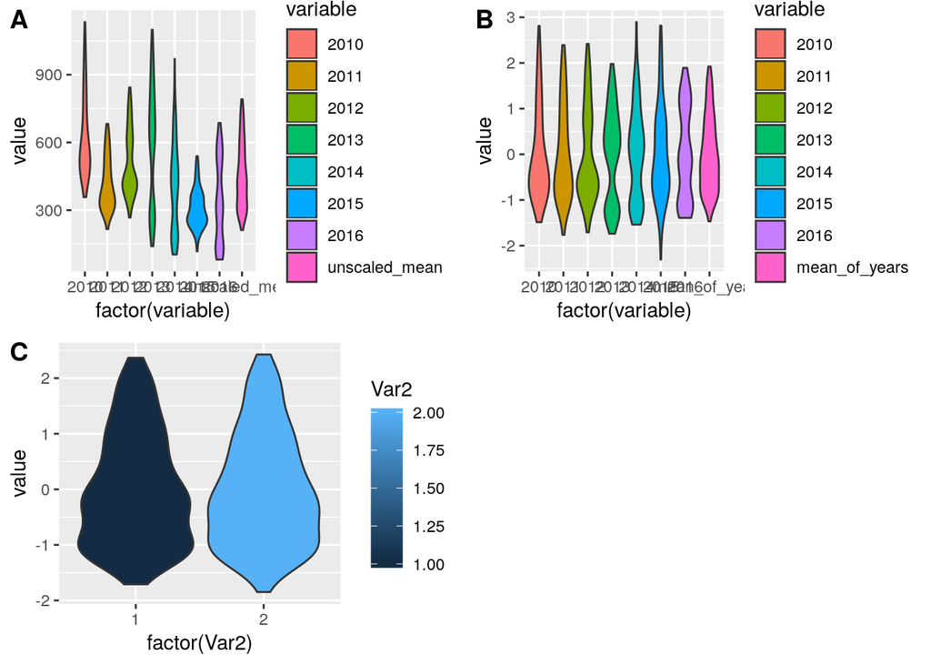

```r
# unscaled
Gtot[, "unscaled_mean" := apply(.SD, 1, mean), .SDcols = names(Gtot)[-1]]
unscaled <- ggplot2::ggplot(data.table::melt(Gtot), ggplot2::aes(factor(variable), value, fill = variable)) + ggplot2::geom_violin() + ggplot2::scale_color_brewer(palette="Set1")
#scaled
scd <- cbind(Gtot[,c("Plot")], apply(Gtot[, c("2010", "2011", "2012", "2013", "2014", "2015", "2016")], 2, scale))
scd[, "mean_of_years" := apply(.SD, 1, mean), .SDcols = names(scd)[-1]]
scaled <- ggplot2::ggplot(data.table::melt(scd), ggplot2::aes(factor(variable), value, fill=variable)) + ggplot2::geom_violin() + ggplot2::scale_color_brewer(palette="Set1")
# comparing means
means <- merge(scd, Gtot, by="Plot")
means <- means[, c("Plot", "mean_of_years", "unscaled_mean")]
one <- scale(means$unscaled_mean)
two <- scale(means$mean_of_years)
test <- cbind(one, two); rm(one); rm(two)
test2 <- data.table::melt(test)

scmeans <- ggplot2::ggplot(test2, ggplot2::aes(factor(Var2), value, fill = Var2)) + ggplot2::geom_violin() +
  ggplot2::scale_color_brewer(palette="Set1")

cowplot::plot_grid(unscaled, scaled, scmeans, labels = c("A","B", "C"))
```

```r
rm(means); rm(scaled); rm(scmeans); rm(test); rm(test2); rm(unscaled)
```

above : A shows the unscaled years and right (pink) the unscaled years. B shows the scaled years and their mean. C plots the scales mean of unscaled years and the scaled mean of scaled years. They are not identical, however, very similar.

If scaling is done, it is done after taking the mean.

```r
Gtot[, "Groundwater.recharge" := apply(.SD, 1, mean), .SDcols = c("2010", "2011", "2012", "2013", "2014", "2015", "2016")]
# scd <- cbind(Gtot[,c("Plot")], apply(Gtot[, c("2010", "2011", "2012", "2013", "2014", "2015", "2016")], 2, scale))
# raw_functions[, "Groundwater.recharge" := rowMeans(scd[, c("2010", "2011", "2012", "2013", "2014", "2015", "2016")])]
raw_functions <- merge(raw_functions, Gtot[, c("Plot", "Groundwater.recharge")], by="Plot", all = T)
rm(Gtot); rm(scd)
list_raw_functions["Groundwater.recharge"] <- NULL
```

# forage quality

RFV : Relative Feed Value RFQ : Relative Forage Quality ADL : acid detergent lignin, Lignin ADF : Acid Detergent Fibre, Säure-Detergenz-Faser, ein Teil der Gerüstsubstanzen von Futtermitteln NDF : Neutral Detergent Fibre, Neutral-Detergenz-Faser, fasrige Anteile von Futtermitteln

according to forage quality estimation based on alfalfa (medicago sativa) values. [source](https://openprairie.sdstate.edu/cgi/viewcontent.cgi?referer=https://scholar.google.ch/&httpsredir=1&article=1351&context=extension_extra)

[% concentration in aboveground grassland plant community biomass without litter]

```r
forage.quality <- list_raw_functions$forage.quality

# 1. calc fq for each plot
forage.quality[, Crude.protein := 6.25*N]
forage.quality[, DDM := 88.9-(0.779* ADF)]
forage.quality[, DMI := 120/NDF]
forage.quality[, RFV := (DDM*DMI)/1.29]
forage.quality[, forage.quality := apply(scale(forage.quality[,c("RFV", "Crude.protein")]), 1, mean)]
# mean of years
forage.quality <- aggregate(forage.quality~Plot_name, forage.quality, mean)
forage.quality <- data.table::data.table(forage.quality)
data.table::setnames(forage.quality, old="Plot_name", new="Plot")

raw_functions <- merge(raw_functions, forage.quality, by="Plot", all=T)

# ohne biomasse - es geht um qualität, oder? "normalisation" der Jahre mit
# biomasse macht keinen sinn, da wir sowieso mit konzentrationen arbeiten...
# oder?


# forage.quality <- list_raw_functions[["forage.quality"]]
# # calculating the columns needed for forage quality calc
# forage.quality[, Crude.protein := 6.25*N]
# forage.quality[, DDM := 88.9-(0.779* ADF)]
# forage.quality[, DMI := 120/NDF]
# forage.quality[, RFV := (DDM*DMI)/1.29]
# forage.quality[, forage.quality := apply(scale(forage.quality[,c("RFV", "Crude.protein")]), 1, mean)]
#
# # take apart the years and add separately to raw_functions
# forage.quality <- forage.quality[,c("Plot", "year", "forage.quality")]
#
# for(i in unique(forage.quality$year)){
#   newname <- paste("forage.quality", i, sep="")
#   fi <- forage.quality[year == i]
#   data.table::setnames(fi, old="forage.quality", new=newname)
#   raw_functions <- merge(raw_functions, fi[,!"year"], by="Plot", all=T)
# }
list_raw_functions["forage.quality"] <- NULL
```

See in compare_raw_function_to_synthesis for yearly calculation!

# P loss / leaching risk

Took reverse values so high values represent low loss and therefore high functioning.

# Herbivory

## 2013

invertebrate herbivory in 146 managed temperate grasslands. Year: 2013

increased land-use - less invertebrates - less herbivory

Visually estimation of herbivory by eye using templates and measurement of leaf area left after feeding of the herbivores using LI-COR area meter

SEG45 : The mean of all 3 samples was already taken and stored as sample2. Taking the mean of samples2 first and then with sample1 would lead to different results than in the synthesis dataset.

note : used measure is very conservative. percent herbivory is on the whole plot, on both grasses and herbs.

```r
Herbivory.2013 <- list_raw_functions$Herbivory.2013

Herbivory.2013 <- aggregate(PercHerbivory~EP_Plotid, Herbivory.2013, mean)
data.table::setnames(Herbivory.2013, old=c("EP_Plotid", "PercHerbivory"), new=c("Plot", "herbivory.2013"))

raw_functions <- merge(raw_functions, Herbivory.2013, by="Plot", all.x=T) ; rm(Herbivory.2013)
list_raw_functions["Herbivory.2013"] <- NULL
```

## 2017 2018

Was read in as it is.

## Combining 2013 with 2017/2018?

Dataset collection differed between them. They do not correlate and their range differ.

```r
m <- lm(raw_functions$herbivory.2013 ~ raw_functions$herbivory.20172018)
summary(m)
```

```
##
## Call:
## lm(formula = raw_functions$herbivory.2013 ~ raw_functions$herbivory.20172018)
##
## Residuals:
##     Min      1Q  Median      3Q     Max
## -0.9964 -0.5136 -0.1997  0.3509  4.4937
##
## Coefficients:
##                                  Estimate Std. Error t value Pr(>|t|)
## (Intercept)                        1.0211     0.1074   9.506   <2e-16 ***
## raw_functions$herbivory.20172018   2.4311     5.1005   0.477    0.634
## ---
## Signif. codes:  0 '***' 0.001 '**' 0.01 '*' 0.05 '.' 0.1 ' ' 1
##
## Residual standard error: 0.7695 on 140 degrees of freedom
##   (8 observations deleted due to missingness)
## Multiple R-squared:  0.00162,    Adjusted R-squared:  -0.005511
## F-statistic: 0.2272 on 1 and 140 DF,  p-value: 0.6344
```

```r
rm(m)
```

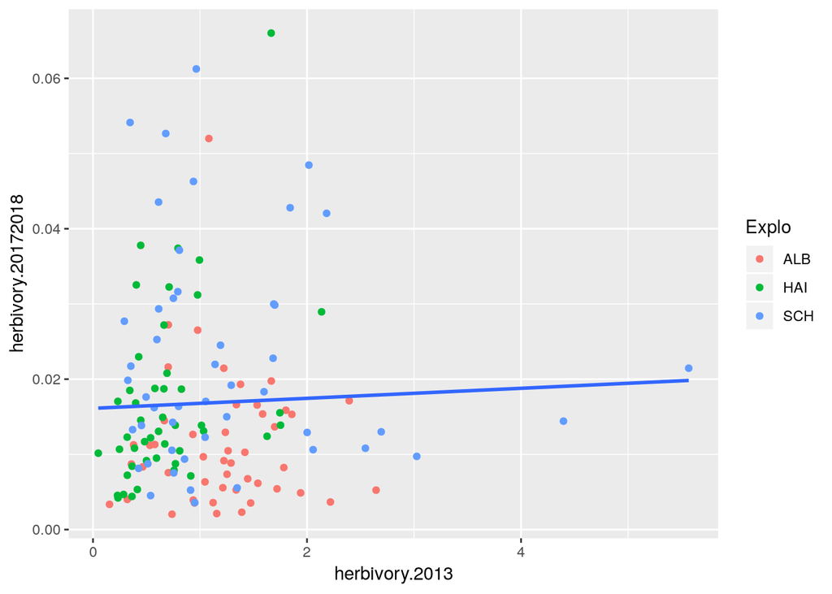

```r
ggplot2::ggplot(raw_functions, ggplot2::aes(x=herbivory.2013, y=herbivory.20172018)) +
  ggplot2::geom_point(ggplot2::aes(colour = Explo)) +
  ggplot2::geom_smooth(method = "lm", se=F)
```

# Litter.decomposition

litter bag approach, Mass loss in the litter bags, after two months, and four months. 1.5g of dry plant material. January 2013 put 10 bags each, 2 months later retrieval of 5 bags, 2 more months : retrieval of other 5 bags. calculated daily decomposition rates.

```r
Litter.decomposition <- list_raw_functions$Litter.decomposition
# take the mean daily decomposition rate over all measures, the ones with 2 months and the ones with 4 months decomposition.
Litter.decomposition <- aggregate(DailyDecompositionRate~EPPlotID, Litter.decomposition, mean)
data.table::setnames(Litter.decomposition, old=c("EPPlotID", "DailyDecompositionRate"), new=c("Plot", "Litter.decomposition"))
raw_functions <- merge(raw_functions, Litter.decomposition, by="Plot", all.x = T) ; rm(Litter.decomposition)
list_raw_functions["Litter.decomposition"] <- NULL
```

# Parasitoid traps

If there are more parasitoid wasps, they predate caterpillars which eat the plants.

Cat : Replace by a better measure (caterpillars predation not found in bexis)

3 datasets (13350, 13347, 13349) for 3 regions: 34 from AEG, 28 from HEG and 34 from SEG - 96 plots measured

recorded total broodcell number : Total_BC_No

```r
# get dataset from raw functions list
pt <- list_raw_functions$Parasitoid.traps
pt <- pt[Function == "Parasitoid", c("PlotID", "Total_BC_No")]
pt <- aggregate(Total_BC_No~PlotID, pt, sum)
data.table::setnames(pt, old=c("PlotID", "Total_BC_No"), new=c("Plot", "Parasitoid.traps"))
# append to raw functions list
raw_functions <- merge(raw_functions, pt, by="Plot", all.x = T); rm(pt)
list_raw_functions["Parasitoid.traps"] <- NULL
```

# Total pollinators

Plot number AEG24 has 939 total pollinators in synthesis dataset, but only 339 total pollinators in the downloaded dataset. All other numbers are perfectly identical.

The number from the downloaded dataset is taken, but the change is recorded.

```r
Total.pollinators <- list_raw_functions$Total.pollinators
Total.pollinators <- aggregate(Total.pollinators~Plot, Total.pollinators, sum)
raw_functions <- merge(raw_functions, Total.pollinators, by="Plot", all=T) ; rm(Total.pollinators)
list_raw_functions["Total.pollinators"] <- NULL
```

# PRI

from synthesis .html :

Phosphorus retention (PRI): Pmic (15766; microbial phosphorus in soil), PlantP.conc (18869; only 2009 data on P concentrations used and multiplied with biomass to give shoot.P.stock) and OlsenPi2014 (19286) [PRI = (shoot.P.stock + Pmic)/(OlsenPi2014 + Pmic + shoot.P.stock)]

*2014* : Pmic.2014, Pshoot.2014, Biomass2014, Bulk.density2014

*2011* : ?

$$PRI = \frac{microbial Phosphorous + plant shoot Phosphorous}{microbial Phosphorous + plant shoot Phosphorous + soil Phosphorous}$$
where
$$microbial Phosphorous = (Pmic (mg/kg) / 1000000) * (bulk density (g/cm^3) * 100000 cm^3/ m^2)$$
$$plant shoot P = Pshoot (\%) * Biomass (g/m^2)$$
$$soil P = \frac{Olsen Pi (mg/kg)}{1000000} * (bulk density (g/cm^3) * 100000 cm^3/ m^2)$$

```r
# 2014
# Pmic.2014 OlsenPi2014 in raw_functions
rPRI <- raw_functions[, c("Plot", "Pmic.2014", "Bulk.density2014", "OlsenPi2014", "Biomass2014")]
nutrients <- list_raw_functions$nutrients

nutrients <- nutrients[, c("Plot", "Pshoot.2014")]
rPRI <- merge(rPRI, nutrients, by="Plot", all=T)

rPRI[, "micPstock":= (Pmic.2014 / 1000000)*(Bulk.density2014 * 100000)]
rPRI[, "soilPstock" := (OlsenPi2014 / 1000000) * (Bulk.density2014 * 100000)]
rPRI[, "plantPstock" := Pshoot.2014 * Biomass2014]
rPRI[, "PRI" := (micPstock + plantPstock)/(micPstock + plantPstock + soilPstock)]
raw_functions <- merge(raw_functions, rPRI[,c("Plot", "PRI")], by = "Plot", all = T)
rm(rPRI); rm(nutrients)
```

# NRI - Nitrogen retention index

requires : Bulk.density2014, Nshoot.2014, NH4.2014, NO3.2014, Biomass2014, Nmic.2014

Most of these datasets are already read in in this script. Nshoot is stored in `list_raw_functions` “nutrients”. Only Nmic.2014 needs to be read in.

```r
nridat <- raw_functions[,c("Plot", "Bulk.density2014", "NH4.2014", "NO3.2014", "Biomass2014", "Nmic.2014")]
Nshoot.2014 <- list_raw_functions$nutrients
Nshoot.2014 <- Nshoot.2014[, c("Plot", "Nshoot.2014")]
nridat <- merge(nridat, Nshoot.2014, by="Plot", all = T); rm(Nshoot.2014)

nridat[, "micNstock":= (Nmic.2014 / 1000000)*(Bulk.density2014 * 100000)]
nridat[, "soilNstock" := ((NH4.2014 + NO3.2014) / 1000000) * (Bulk.density2014 * 100000)]
nridat[, "plantNstock" := Nshoot.2014 * Biomass2014]
nridat[, "NRI" := (micNstock + plantNstock)/(micNstock + plantNstock + soilNstock)]
raw_functions <- merge(raw_functions, nridat[,c("Plot", "NRI")], by = "Plot", all = T) ; rm(nridat)
list_raw_functions["nutrients"] <- NULL
```

# N leaching risk

Took reverse such that high values represent low leaching risk and therefore high functioning.

# pathogen infection

plant cover data: - took together all Poa because pathogen data recorded host Poa species as “Poa” only - created plant abbreviation reference table, because pathogen data host species (plants) were recorded with abbreviated names only - multiplied infection severity per plant species with the according plant species cover on each plot separately.

```r
pat <- list_raw_functions$pathogen.infection
npla <- list_raw_functions$plant.cover
list_raw_functions["plant.cover"] <- NULL
list_raw_functions["pathogen.infection"] <- NULL

tot.infect <- with(pat, perc_plants_infected*perc_infection_severity)/10000   ### calculate infection as prop plants infected x mean severity of infection per plant

##### SB only identified Poa to genus, so need to combine Poas in Barbara data
# aggregate all Poa from same plots
Poa <- aggregate(Cover~Plot, npla[grep("Poa", Species)], sum)
Poa <- data.table::as.data.table(Poa)
# add column for "Species" to Poa
Poa[, Species := "Poa"]
npla <- rbind(npla[-grep("Poa", Species)], Poa); rm(Poa)

### total infection per plant species per plot
# aggregate different pathogens per plant and plot (for all plant species which are affected by more than one pathogen) with cbind(pat, tot.infect)
# aggregate
p.infect <- aggregate(tot.infect~Plot+host, cbind(pat, tot.infect), sum)
rm(pat); rm(tot.infect)
```

### Plant abbreviations reference table.

```r
### generate plant name reference table from npla and p.infect
# to find back host species in plant cover data
Speciesref <-unique(npla$Species)
pla_reftable <- data.table::data.table("Abbrev" = as.character(unique(p.infect$host)))
# create regex searchpattern
pla_reftable[, "pattern" := lapply(Abbrev, function(w) paste(strsplit(w, split=NULL)[[1]], sep="", collapse=".{0,10}"))]
# find pattern in plantcover data
pla_reftable[, "Species" := lapply(pattern, function(p) unique(Speciesref[grep(p, Speciesref, perl=T)]))]
pla_reftable[, "pattern" := NULL] ; rm(Speciesref)
# resolve rows with more than one match
# is there another, unique match? If yes, the unique match is taken out from the double matches.
len <- length(pla_reftable$Species[which(lengths(pla_reftable$Species) > 1)])
for(i in 1:(len-1)){
  e <- pla_reftable$Species[which(lengths(pla_reftable$Species) > 1)][[i]]
  if(any(e %in% pla_reftable$Species[which(lengths(pla_reftable$Species) == 1)])){
    # if one of the species names was identified as "single", delete it from the double one.
    ne <- e[-which(e %in% pla_reftable$Species[which(lengths(pla_reftable$Species) == 1)])]
    # store new species names
    pla_reftable$Species[which(lengths(pla_reftable$Species) > 1)][[i]] <- ne
  }
}
rm(i); rm(e); rm(len); rm(ne)
# still some doubles left. By hand.
pla_reftable[Abbrev == "Achmil", Species := as.list("Achillea_millefolium_aggr.")]  # and not "Alchemilla_vulgaris_aggr." (1)
pla_reftable[Abbrev == "Arrela", Species := as.list("Arrhenatherum_elatius")]  # and not "Arenaria_serpyllifolia" (11)
pla_reftable[Abbrev == "Caracu", Species := as.list("Carex_acutiformis")]  # and not "Campanula_rapunculoides" or "Carlina_acaulis" (17)
pla_reftable[Abbrev == "Carfla", Species := as.list("Carex_flacca")]  # and not "Campanula_persicifolia,Campanula_rotundifolia,Carduus_defloratus" (18)
pla_reftable[Abbrev == "Crulae", Species := as.list("Cruciata_laevipes")]  # and not "Cirsium_vulgare" (27)
pla_reftable[Abbrev == "Eupros", Species := as.list("Euphrasia_rostkoviana_aggr.")]  # and not "Euphorbia_helioscopia" (35)
pla_reftable[Abbrev == "Falvul", Species := as.list("Falcaria_vulgaris")]  # and not "Fallopia_convolvulus" (37)
pla_reftable[Abbrev == "Gentin", Species := as.list("Genista_tinctoria")]  # and not "Gentiana_verna,Gentianella_germanica" (47)
pla_reftable[Abbrev == "Gerpra", Species := as.list("Geranium_pratense")]  # and not "Geranium_pyrenaicum" (49)
pla_reftable[Abbrev == "Plalan", Species := as.list("Plantago_lanceolata")]  # and not "Platanthera_chlorantha" (67)
pla_reftable[Abbrev == "Plamaj", Species := as.list("Plantago_major")]  # and not "Pimpinella_major" (68)
pla_reftable[Abbrev == "Symoff", Species := as.list("Symphytum_officinale")]  # and not "Sisymbrium_officinale" (88)
pla_reftable[Abbrev == "Trifla", Species := as.list("Trisetum_flavescens")]  # and not "Trifolium_alpestre, Trifolium_arvense, Trifolium_campestre, Trifolium_montanum, Trifolium_pratense" (91)
pla_reftable[Abbrev == "Tripra", Species := as.list("Trifolium_pratense")]  # and not "Tripleurospermum_perforatum" (92)
pla_reftable[Abbrev == "Trirep", Species := as.list("Trifolium_repens")]  # and not "Tripleurospermum_perforatum" (93)
pla_reftable[Abbrev == "Vicsep", Species := as.list("Vicia_sepium")]  # and not "Veronica_serpyllifolia" (96)
# delete
pla_reftable <- pla_reftable[Abbrev != "Des", ] # because only Deschampsia_cespitosa which has Abbreviation Desces (30)

# change Fes to "Fesaru", because " Festuca_arundinacea" is only (logical) member of "Fes" (38) - other members were Festulolium_loliaceum,Fragaria_vesca,Fraxinus_excelsior
# there is already a line for it.
pla_reftable <- pla_reftable[Abbrev == "Fes", Abbrev := "Fesaru"]
pla_reftable[Abbrev == "Fesaru", Species := as.list("Festuca_arundinacea")] # and not "Festulolium_loliaceum,Fragaria_vesca,Fraxinus_excelsior"
# 19: Carhir  Carex_hirta,Cardamine_hirsuta
# sum(npla[Species == "Carex_hirta",Cover]) # 124.2
# sum(npla[Species == "Cardamine_hirsuta",Cover]) # 0
# There is no cover of Cardamine hirsuta, therefore take Carex hirta
pla_reftable[Abbrev == "Carhir", Species := as.list("Carex_hirta")]  # and not "Cardamine_hirsuta" (19)
# combine "Poa_annua", "Poa_pratensis_aggr.", "Poa_sp", "Poa_trivialis" to "Poa"
npla$Species[grep("Poa", npla$Species)] <- "Poa"
pla_reftable[Abbrev == "Poa", Species := as.list("Poa")]
# Rumace : put together acetosa and acetosella in plantcover
# 81: Rumace   Rumex_acetosa,Rumex_acetosella
# sum(npla[Species == "Rumex_acetosa",Cover]) # 152
# sum(npla[Species == "Rumex_acetosella",Cover]) # 13
npla$Species[grep("Rumex_a", npla$Species)] <- "Rumex_acetos."
pla_reftable[Abbrev == "Rumace", Species := as.list("Rumex_acetos.")]
# Note : the below by-hand changes were only done for very small total infection rates (see table below) with max 3.6 and mean 0.42
# host tot.infect
# 1  Atrpat    0.00050
# 2  Eupmin    0.00105
# 3  Fessp.    0.02100
# 4  Galalb    0.00175
# 5  Polamp    0.00490
# 6  Potsp.    0.15000
# 7  Rhiale    0.06270
# 8  Rhimin    0.00525
# 9  Rossp.    0.74150
# 10 Sissp.    0.09000
# 11 Tarrud    3.61925

# abbreviation "Tarrud" with no match in plantcover
# Is most probably referring to "Taraxacum ruderalia
pla_reftable[Abbrev == "Tarrud", Species := as.list("Taraxacum_sp")]
# abbreviation "Sissp." with no match in plantcover
# Is most probably referring to Sisymbrium_officinale
pla_reftable[Abbrev == "Sissp.", Species := as.list("Sisymbrium_officinale")]
# Potsp. with no match in plantcover
# most probably is a Potentilla. but which? Potentilla reptans is the most common one.
pla_reftable[Abbrev == "Potsp.", Species := as.list("Potentilla_reptans")]
# Fessp. : most probably is Festuca species, but which? "Festuca_arundinacea", "Festuca_ovina_aggr.", "Festuca_pratensis", "Festuca_rubra_aggr."
# Festuca_rubra_aggr is the most common, followed by Festuca_pratensis.
# put to Festuca_rubra_aggr.
pla_reftable[Abbrev == "Fessp.", Species := as.list("Festuca_rubra_aggr.")]
# Polamp : assume typo - change to Polygala_amarella
pla_reftable[Abbrev == "Polamp", Species := as.list("Polygala_amarella")]
# Rhiale and Rhimin : most probably is part of Rhinanthus_aggr (the only species name starting with "Rhi")
pla_reftable[Abbrev == "Rhiale", Species := as.list("Rhinanthus_aggr.")]
pla_reftable[Abbrev == "Rhimin", Species := as.list("Rhinanthus_aggr.")]
# Rossp. : most probably part of "Rosa_sp" (the other option would be Rosa_canina_aggr., so it does not matter too much)
pla_reftable[Abbrev == "Rossp.", Species := as.list("Rosa_sp")]
# Atrpat : could be Agrimonia_eupatoria, but this doesn't seem probable. Don't include.

# Galalb : "Galeopsis_sp"         "Galium_aparine"       "Galium_mollugo_aggr." "Galium_pumilum"       "Galium_verum"
# is there a alb in one of the aggregates? Not for Galeopsis. For Galium molluno aggr. it would be a very strange abbreviation.
# very very small amount of tot. infection - can leave out.

# Eupmin : no probable candidate, leave out (very small number)


# -----------------------------------------Code which is useful to search things
# pla_reftable$Abbrev[which(lengths(pla_reftable$Species) < 1)]
# # p.infect[which(p.infect$host %in% pla_reftable$Abbrev[which(lengths(pla_reftable$Species) < 1)]),]
# aggregate(tot.infect~host, p.infect[which(p.infect$host %in% pla_reftable$Abbrev[which(lengths(pla_reftable$Species) < 1)]),], sum)
#
# unique(npla$Species[grep("Pot", npla$Species)])
# # look up amount of plant cover.
# sum(npla[grep("Potentilla_verna_aggr.", npla$Species), Cover])

# make Species column as character
pla_reftable[, "Species" := as.character(Species)]
```

```r
# Translate p.infect Abbreviated species names to long names as used in plantcover data
data.table::setnames(pla_reftable, old="Abbrev", new="host")
p.infect <- merge(p.infect, pla_reftable, by="host", all.x=T)

pinf <- merge(p.infect, npla, by=c("Plot", "Species"), all.x=T)
pinf <- data.table::as.data.table(pinf)
###### multiply total infection by relative cover of plant species, assume that a missing species is not infected.
pinf[, p.inf := tot.infect * (Cover/100)]
pathogen.infection <- aggregate(p.inf~Plot, pinf, sum)
data.table::setnames(pathogen.infection, old=c("p.inf", "Plot"), new=c("pathogen.infection", "Plotn"))
pathogen.infection <- data.table::as.data.table(pathogen.infection)

raw_functions <- merge(raw_functions, pathogen.infection, by="Plotn", all=T) ; rm(pathogen.infection)
rm(pla_reftable); rm(npla); rm(p.infect); rm(pinf)
```

# dung decomposition

Taking the mean over all 5 dung types for each plot. Dung removal in g and not in %, because the treatments (dung types) were (almost) the same in all plots and can therefore be compared.

```r
dung.decomposition <- list_raw_functions[["dung.decomposition"]]
# scale values for dungtype to be able to combine different dungtypes
dung.decomposition[, scaled_removal_g := lapply(.SD, function(x) as.vector(scale(x))), by = dungtype, .SDcols = "removal_g"]
dd <- data.table::copy(dung.decomposition)

dung.decomposition <- aggregate(scaled_removal_g~EP, dung.decomposition, mean)
data.table::setnames(dung.decomposition, old = c("EP", "scaled_removal_g"), new=c("Plot", "dung.decomposition"))
raw_functions <- merge(raw_functions, dung.decomposition, by = "Plot", all = T)
list_raw_functions["dung.decomposition"] <- NULL
```

graphical representation

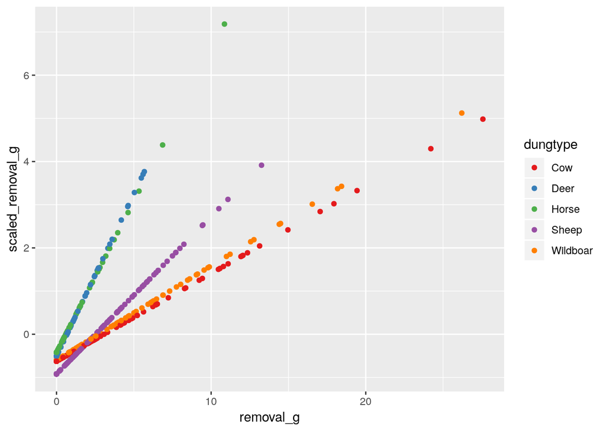

```r
ggplot2::ggplot(data = dd, ggplot2::aes(x = removal_g, y = scaled_removal_g, colour = dungtype)) +
  ggplot2::geom_point() +
  ggplot2::scale_color_brewer(palette="Set1")
```

```r
rm(dung.decomposition); rm(dd)
```

# calc combined functions “mini- multifunctionalities”

Assembled functions were constructed according to E. Allan (cite project?).

## Tests for Mini-Multifunc

The below code contains considerations about the grouping of the mini-multifunctionalities. It appears that some of them do not correlate with each other as expected.

```r
source("input_for_2calc.R")
# contains correlation plots, correlation networks and a pca
```

## soilCflxs

Enzymes related to soil C. All measured in the year 2011.

```r
sce <- raw_functions[, c("beta_Glucosidase", "N_Acetyl_beta_Glucosaminidase", "Xylosidase")]
# take z-scores of the functions
raw_functions[, "soilCflxs" := multidiv(sce, sc="sd", cent=TRUE)[,1]]
rm(sce)
```

## soilNflxs

Enzymes related to soil N. A measure of soil N cycling with enzyme activities and functional gene abundances

amoA_AOB and A are from both 2011 and 2016, took the mean of both years.

```r
nce <- raw_functions[,c("Urease", "DEA","Potential.nitrification2011", "Potential.nitrification2014","nifH","amoA_AOB.2011","amoA_AOA.2011", "amoA_AOB.2016", "amoA_AOA.2016", "nxrA_NS", "16S_NB")]
# take mean of multi-year-measurements
nce[, "amoA_AOB" := apply(nce[,c("amoA_AOB.2011", "amoA_AOB.2016")],1, mean)]
nce[, "amoA_AOA" := apply(nce[,c("amoA_AOA.2011", "amoA_AOA.2016")],1, mean)]
nce[, "Potential.nitrification" := apply(nce[, c("Potential.nitrification2014", "Potential.nitrification2011")], 1, mean)]
nce[, c("amoA_AOB.2011", "amoA_AOB.2016", "amoA_AOA.2011", "amoA_AOA.2016", "Potential.nitrification2014", "Potential.nitrification2011") := NULL]

raw_functions[, "soilNflxs" := multidiv(nce, sc="sd", cent=TRUE)[,1]]
rm(nce)
```

## P_loss_comb

combination of PRI and P_loss/ P_leaching risk.

```r
plc <- raw_functions[, c("P_loss2011", "P_leaching_risk2015", "PRI")]
# take mean of P_loss 2011 and leaching risk 2015
plc[, "P_loss" := apply(plc[,c("P_loss2011", "P_leaching_risk2015")],1, mean)]
plc[, c("P_loss2011", "P_leaching_risk2015") := NULL]
raw_functions[, "P_loss_comb" := multidiv(plc, sc="sd", cent=TRUE)[,1]]; rm(plc)
```

## N_loss_comb

Could be calculated as P_loss_comb, if NRI and N loss (or N leaching risk) were measured in the same year.

# store assembled dataset

clean unneeded variables

```r
rm(list_raw_functions); rm(info_data)
```

store as .csv document

```r
cat("Dear user, \n
    Please enter a prefix (=piece of the name which is printed in front of a file).\n
    It will be used for the assembled functions dataset.\n
    The dataset will be printed on your Desktop with the prefix you have given together with the following suffix :\n
    '_raw_functions_dataset.csv' \n
    example : 'december2018' would give 'december2018__raw_functions_dataset.csv'")
```

```
## Dear user,
##
##     Please enter a prefix (=piece of the name which is printed in front of a file).
##
##     It will be used for the assembled functions dataset.
##
##     The dataset will be printed on your Desktop with the prefix you have given together with the following suffix :
##
##     '_raw_functions_dataset.csv'
##
##     example : 'december2018' would give 'december2018__raw_functions_dataset.csv'
```

```r
prefix <- readline(prompt="Write now : ")
#USER : change ~/Desktop/ to the directory where the dataset should be stored.
#  if you don't know what to write, just write nothing : "" (empty)
write.table(raw_functions, file=paste("", prefix, "_raw_functions_dataset.csv", sep=""), sep=";", row.names = F)
rm(prefix)
```

select variables used in BetaDivMultifun and variables used to calculate them:

```r
raw_functions_betadivmultifun_raw <- raw_functions[, selection, with=F]
raw_functions_betadivmultifun <- raw_functions[, s3, with=F]
write.table(raw_functions_betadivmultifun, file="~/Desktop/functions_dataset_april2019.csv", sep=",", row.names = F)
```